# The Adoption of Canvas as a Learning Management System by The University of Sydney Students

Project 3

Lewis Krishnamurti - 490294583, Sharaf Fozdar - 480438353, Alvin Peng - 480188609, Alex Chen - 490404001

University of Sydney | DATA1001 | MAY 2019

# 1 Executive Summary

We wanted to determine how successful the introduction of canvas was to USYD in 2018, both in terms of how well it was integrated and adopted by students and how useful the students found it, especially in terms of improving marks. We found that canvas has been adopted and is being used regularly by most of the student population and across all age groups, though a drop-off in usage in semester 2 suggests that some did not find it useful. Also there was no definitive evidence that regular canvas usage results in better marks for students or that courses which emphasise canvas produce higher marks.

# 2 Initial Data Analysis (IDA)

The purpose of this report is to outline to The University of Sydney how the full adoption of Canvas in 2018 (The University of Sydney, 2019) has been received by students, both in terms of how well it was integrated and adopted by students and if they found it useful, especially in terms of their marks. This information would be useful to the University as it would provide insight into how successful the change in learning management system from Blackboard to Canvas has been and if the University should place a greater emphasis on the online learning environment provided through the use of Canvas. The dataset provided by the Institutional Analytics and Planning (IAP) department of the University provides information about different variables about students who studied different junior mathematics units in 2018. Given that the IAP has removed all identifying information of the students in the dataset it can be deemed ethical in the sense that no student can be personally identified, except possibly by the student’s themselves if they recognise a mark that only they received. The dataset is limited in various ways such as that it only contains information about junior mathematics units, which does not represent the entire student body using canvas. Students who did not access Canvas at all during the semester have also been removed from the dataset, as well as it not being known how many times a week a student accessed Canvas, only whether they accessed it or not. This means that the dataset possibly does not reflect entirely how well each student used or did not use Canvas as a resource to amplify their learning.

```r
library(ggplot2)
data = read.csv("Data.csv")
data$weeks_accessed = data$Canvas.access.Week.1 + data$Canvas.access.Week.2 + data$Canvas.access.Week.3 + data$Canvas.access.Week.4 + data$Canvas.access.Week.5 + data$Canvas.access.Week.6 + data$Canvas.access.Week.7 + data$Canvas.access.Week.8 + data$Canvas.access.Week.9 + data$Canvas.access.Week.10 + data$Canvas.access.Week.11 + data$Canvas.access.Week.12 + data$Canvas.access.Week.13 + data$Canvas.access.Mid.semester.break + data$Canvas.access.STUVAC
```

# 3 Research Question

Our research question is how successful was the introduction of canvas to the University of Sydney last year? We examined this in terms of how well it was integrated and adopted by students and if the students found it useful (and if it improved their marks). Canvas, a relatively new Learning Management System which has attained high popularity over recent years, is considered an easily accessible LMS with a wide range of content features, some of which other programs like Blackboard and Moodle do not have (Kuran, Pedersen, & Elsner, 2017). Our goal is to see how the students react to the new technology.

## 3.1 Part 1

[figure not shown]

```r
f11 = ggplot(data, aes(fill=data$weeks_accessed=="15", x=data$Unit.of.Study.Identifier, y =data$weeks_accessed))
f11 + ylab("Proportion of Students") + xlab("Unit of Study") + geom_bar(stat="identity", position = "fill") + labs(fill = "Test") + ggtitle("Figure 1.1: Proportion of Students Accessing Canvas Every Week by Unit of Study") + scale_fill_manual(values=c("#BFD5E3","#999999")) + theme(panel.background = element_rect(fill = "#BFD5E3"), legend.position = "none")
```

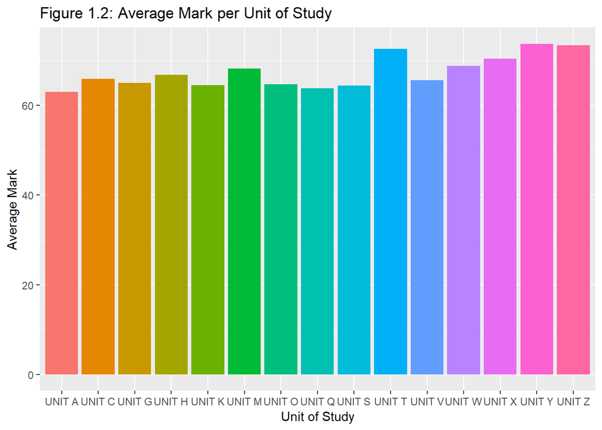

```r
ggplot(data, aes(data$Unit.of.Study.Identifier, data$Mark, fill=data$Unit.of.Study.Identifier)) + geom_bar(aes(data$Unit.of.Study.Identifier, data$Mark, fill = data$Unit.of.Study.Identifier), position = "dodge", stat = "summary", fun.y = "mean") + ggtitle("Figure 1.2: Average Mark per Unit of Study") + xlab("Unit of Study") + ylab("Average Mark") + theme(legend.position = "none")
```

We wanted to determine whether units of study which make greater use of canvas and whose students thus access canvas more often are more likely to produce higher marks than units of study that use canvas less. If units which base more of their courses around canvas produce better marks then we can judge canvas to be having a positive effect. Accordingly we compared the average marks of the units of study with what percentage of the students used canvas every week. The data indicates that Units like A and Y utilise canvas a great deal, as can be seen by 90% of their students accessing it every week, contrasting with units like T in which only 50% of students access every week. However, a unit’s greater use of canvas does not appear to improve the students’ average marks and according to Figure 1.1 and 1.2 there appears to be no correlation between the two. For instance Unit A has an average mark of 63%, the lowest of the set, compared to Unit Y which has the highest mark at 74%. These results are indicative that units which base their courses around canvas are not more likely to produce better marks and thus that canvas has no particular positive effect on student marks.

## 3.2 Part 2

[figure not shown]

```r
dat = data.frame(Age = factor(c("18 and Under","Over 18"), levels=c("18 and Under","Over 18")), props = c(0.79, 0.75)) # Proportions calculated by filtering the dataset
ggplot(data=dat, aes(x=Age, y=props)) + geom_bar(stat="identity") + ylim(0,0.8) + ylab("Proportion of Students") + xlab("Age of Students") + ggtitle("Figure 2.1: Proportion of Students 18 and Under Accessing Canvas Each Week")
```

[figure not shown]

```r
f22 = ggplot(data, aes(fill=data$weeks_accessed=="15", x=data$Age.Category, y =data$weeks_accessed))
f22 + ylab("Proportion of Students") + xlab("Age Category") + geom_bar(stat="identity", position = "fill") + labs(fill = "Accessed Every Week") + ggtitle("Figure 2.2: Proportion of Students Accessing Canvas Every Week by Age Group")
```

The University of Sydney adopted Canvas for the first time in 2018, presenting differing scenarios for incoming students and students already at USYD. The students who arrived in 2018 had no experience doing university work without canvas, unlike more experienced students who had already formulated study schedules and strategies without canvas. Thus the two groups would absorb the system in very different ways, with it often being the case that the ‘higher a person’s age, the more likely he/she is to perceive a new Learning Management System more negatively’ due to them already having established habits and methods (Claar, Portolese Dias, & Shields, 2014). Therefore if canvas was found to be truly useful by the majority of the student population, then the percentage of students who used canvas regularly would be spread equally across all age groups. According to Figure 2.1 incoming students (18 and under) are 4% more likely to use canvas regularly when compared to all other age groups. However, as can be seen in Figure 2.2 this is due to variation amongst the other age categories, and thus is not significant. Therefore it appears that canvas has been adopted equally across all age groups at USYD, and has thus been found useful by most of the USYD student population.

## 3.3 Part 3

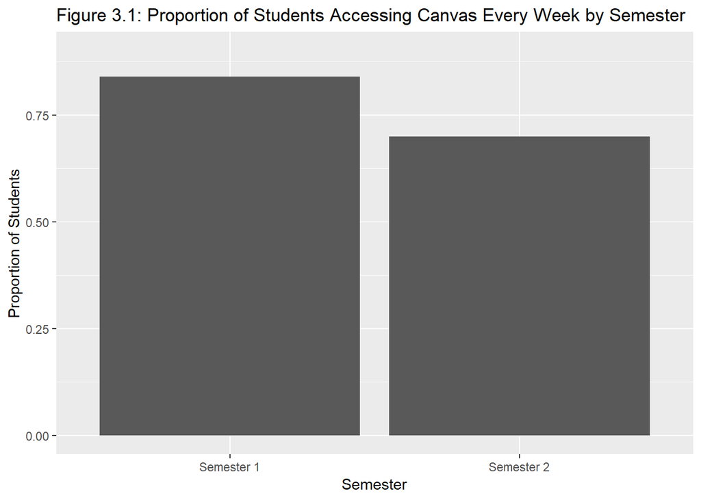

```r
dat2 = data.frame(semester = factor(c("Semester 1","Semester 2"), levels=c("Semester 1","Semester 2")), props = c(0.84, 0.70)) # Proportions calculated by filtering the dataset
ggplot(data=dat2, aes(x=semester, y=props)) + geom_bar(stat="identity") + ylim(0,0.9) + ylab("Proportion of Students") + xlab("Semester") + ggtitle("Figure 3.1: Proportion of Students Accessing Canvas Every Week by Semester")
```

We then determined whether students were more likely to use canvas regularly (every week) in semester 1 or semester 2. If canvas usage remained steady or increased in semester 2 then it would mean that students were finding it useful for their studies, if however students used canvas less in semester 2 then obviously the they did not find it useful. According to Figure 3.1 84% of semester 1 students used canvas every week, compared to only 70% of semester 2 students. This represents a significant drop-off in the percentage of students who use canvas regularly, and indicates that many students did not find canvas particularly helpful and thus used it less as the year progressed. However, a significant proportion of the student population continued to use canvas regularly, so we can not conclude that all or even most of the students were dissatisfied. A limitation of this aspect of our study is that some students begin their year in semester 2, and so will not have encountered canvas before.

## 3.4 Part 4

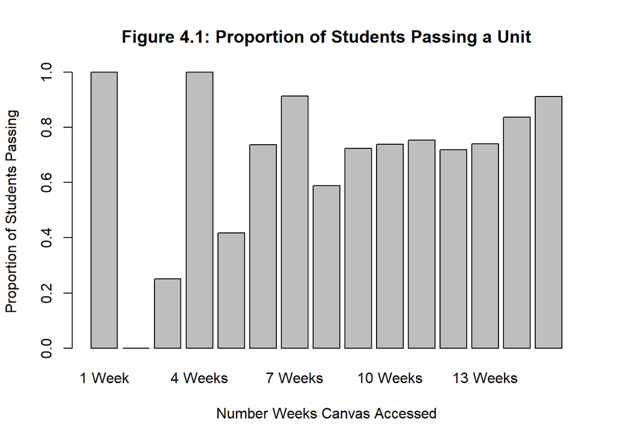

```r
week1 = data$Mark[data$weeks_accessed=="1"]
week2 = data$Mark[data$weeks_accessed=="2"]
week3 = data$Mark[data$weeks_accessed=="3"]
week4 = data$Mark[data$weeks_accessed=="4"]
week5 = data$Mark[data$weeks_accessed=="5"]
week6 = data$Mark[data$weeks_accessed=="6"]
week7 = data$Mark[data$weeks_accessed=="7"]
week8 = data$Mark[data$weeks_accessed=="8"]
week9 = data$Mark[data$weeks_accessed=="9"]
week10 = data$Mark[data$weeks_accessed=="10"]
week11 = data$Mark[data$weeks_accessed=="11"]
week12 = data$Mark[data$weeks_accessed=="12"]
week13 = data$Mark[data$weeks_accessed=="13"]
week14 = data$Mark[data$weeks_accessed=="14"]
week15 = data$Mark[data$weeks_accessed=="15"]
week1p = (length(week1[week1>=50]))/(length(week1))
week2p = (length(week2[week2>=50]))/(length(week2))
week3p = (length(week3[week3>=50]))/(length(week3))
week4p = (length(week4[week4>=50]))/(length(week4))
week5p = (length(week5[week5>=50]))/(length(week5))
week6p = (length(week6[week6>=50]))/(length(week6))
week7p = (length(week7[week7>=50]))/(length(week7))
week8p = (length(week8[week8>=50]))/(length(week8))
week9p = (length(week9[week9>=50]))/(length(week9))
week10p = (length(week10[week10>=50]))/(length(week10))
week11p = (length(week11[week11>=50]))/(length(week11))
week12p = (length(week12[week12>=50]))/(length(week12))
week13p = (length(week13[week13>=50]))/(length(week13))
week14p = (length(week14[week14>=50]))/(length(week14))
week15p = (length(week15[week15>=50]))/(length(week15))
weekspass = c(week1p,week2p,week3p,week4p,week5p,week6p,week7p,week8p,week9p,week10p,week11p,week12p,week13p,week14p,week15p)
barplot(weekspass, main="Figure 4.1: Proportion of Students Passing a Unit", xlab = "Number Weeks Canvas Accessed", ylab= "Proportion of Students Passing", names.arg = c("1 Week", "2 Weeks", "3 Weeks", "4 Weeks", "5 Weeks", "6 Weeks", "7 Weeks", "8 Weeks", "9 Weeks", "10 Weeks", "11 Weeks", "12 Weeks", "13 Weeks", "14 Weeks", "15 Weeks"))
```

We wanted to investigate whether or not Canvas usage affected the pass rate across all units of study. This was done by calculating the proportion of students with a final mark of 50 or above grouped by the number of weeks they accessed Canvas. It was initially hypothesized that the groups of students who used canvas more weeks than others would have higher pass rates. From figure 4.1 it can be seen that there is possibly a slight positive correlation between Canvas usage in this sense and the pass rate of students. Although the students who accessed Canvas in only one week had a 100% pass rate, this is likely skewed by the fact that there were only two students in the dataset who accessed Canvas in only one week, however interestingly the two students who accessed Canvas in two weeks both failed their unit. The pass rate remains relatively similar throughout 9-13 weeks accessed before increasing for students who accessed Canvas 14 and 15 weeks. Due to confounding factors it cannot be concluded whether or not Canvas access has an impact on the pass rate or not, however Canvas access may provide clues as to the work ethic of students (i.e students who don’t access canvas as often may not study as much as those who do.)

## 3.5 Conclusion

Based on our results we can conclude that canvas has been adopted by most of the student population and across all age groups, even though there was a drop-off in the percentage of regular users in Semester 2 which suggests that some did not find it useful. In terms of improving marks, there is no definitive evidence that regularly using canvas improves a student’s marks or that courses with higher canvas usage result in higher marks.

# 4 References

The University of Sydney. (2019, January 08). Learning in Canvas. Retrieved May 25, 2019, from https://sydney.edu.au/students/canvas.html

Kuran, M. Ş, Pedersen, J. M., & Elsner, R. (2017). Learning Management Systems on Blended Learning Courses: An Experience-Based Observation. Image Processing and Communications Challenges 9 Advances in Intelligent Systems and Computing, 141-148. doi:10.1007/978-3-319-68720-9_17

Claar, C., Portolese Dias, L., & Shields, R. (2014). STUDENT ACCEPTENCE OF LEARNING MANAGEMENT SYSTEMS: A STUDY ON DEMOGRAPHICS. Issues in Information Systems, 15(I), 409-417. Retrieved from http://iacis.org/iis/2014/77_iis_2014_409-417.pdf